# Unit 2 Project

Kyle Weber

Due: Tuesday, October 28, 2025

## Front Matter

```r
#Load libraries
library(ggplot2)
library(dplyr)
library(readr)
library(tidyverse)
library(glmnet)
library(pls)
library(mgcv)
COD <- read_csv("C:/Users/3kw10/Downloads/STA508/datasets/STAT508_CODGamesP2.csv")
CODfull <- subset(COD, FullPartial == "Full")
apply(CODfull, 2, function(x) sum(is.na(x)))
```

```
##             Level       FullPartial   PlayerTeamScore OpponentTeamScore
##                 0                 0                 0                 0
##      Eliminations            Deaths             Score            Damage
##                 0                 0                 0                 0
##           TotalXP            XPType              Mode              Game
##                 0                 0                 0                 0
```

## Task 1

#### Analysis and Discussion of Method used for Calculating XP

The method used for calculating TotalXP involved looking at the variable XPType to determine if it is Regular or Double XP being calculated. The boxplot of TotalXP by XPType shows some differences between the levels Regular and Double XP. Double XP has a visibly larger median and variance than Regular, showing that Double XP results in more experience points. This is confirmed by the summary statistics with Double XP having a median of 17399 and standard deviation of 5587.141 vs Regular’s median of 9398 and standard deviation of 3362.117. The values confirm that Double XP does result in nearly twice the TotalXP than Regular does.

During modeling, XPType will be used as a categorical predictor that is transformed into a dummy variable, either 1 or 0 depending on the level. This approach will allow it to be used in models that can not handle categorical variables without transformation. Given its extremely large difference between the two levels and fundamental correlation with XPTotal this will have to be incorporated into the following models.

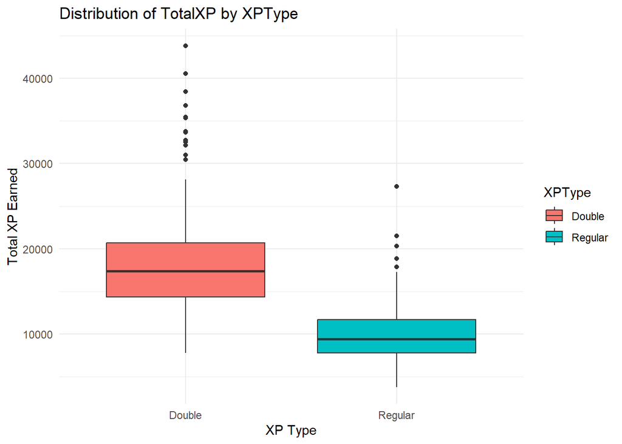

```r
# ggplot
ggplot(CODfull, mapping = aes(x = XPType, y = TotalXP, fill = XPType)) +
  geom_boxplot() +
  labs(title = "Distribution of TotalXP by XPType",
       x = "XP Type",
       y = "Total XP Earned") +
  theme_minimal()
```

```r
# summary statistics
xp_summary <- CODfull %>%
  group_by(XPType) %>%
  summarise(
    mean_XP   = mean(TotalXP, na.rm = TRUE),
    median_XP = median(TotalXP, na.rm = TRUE),
    sd_XP     = sd(TotalXP, na.rm = TRUE),
    n         = n()
  )
print(xp_summary)
```

```
## # A tibble: 2 × 5
##   XPType  mean_XP median_XP sd_XP     n
##   <chr>     <dbl>     <dbl> <dbl> <int>
## 1 Double   18136.     17399 5587.   311
## 2 Regular  10003.      9398 3362.   181
```

#### Analysis and Discussion of the Mode

Looking at the boxplot between Total XP and Mode shows that both levels seemingly have similar deviations with Hardcore’s deviation potentially being larger with more outliers present. However, Core has a larger median that Hardcore, indicating that Core matches result in more TotalXP. The summary statistics show Core has a median of 16300.5 with a standard deviation of 5636.256 while Hardcore has a median of 11533.0 and standard deviation of 6415.151. The results confirm the differences seen in the boxplot, with the outcome maybe being related to integral gameplay differences between the two modes.

Again, when it comes to modeling, Mode as a categorical variable it will need to be transformed into a dummy variable to be used with the coming models. The large difference between the two in terms of mean XP means that it should be included in the following models, but its large variance might affect its actual significance.

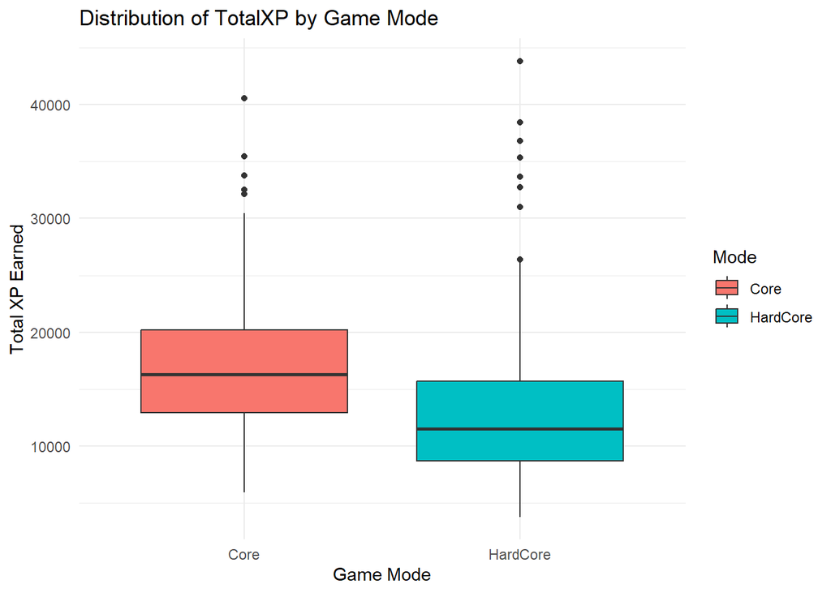

```r
# ggplot
ggplot(CODfull, mapping = aes(x = Mode, y = TotalXP, fill = Mode)) +
  geom_boxplot() +
  labs(title = "Distribution of TotalXP by Game Mode",
       x = "Game Mode",
       y = "Total XP Earned") +
  theme_minimal()
```

```r
# summary statistics
mode_summary <- CODfull %>%
  group_by(Mode) %>%
  summarise(
    mean_XP   = mean(TotalXP, na.rm = TRUE),
    median_XP = median(TotalXP, na.rm = TRUE),
    sd_XP     = sd(TotalXP, na.rm = TRUE),
    n         = n()
  )
print(mode_summary)
```

```
## # A tibble: 2 × 5
##   Mode     mean_XP median_XP sd_XP     n
##   <chr>      <dbl>     <dbl> <dbl> <int>
## 1 Core      16776.    16300. 5636.   280
## 2 HardCore  12988.    11533  6415.   212
```

## Task 2

### Part 1

I will be incorporating seven predictor variables into each of the following three models with the variables being selected based on both logical and statistical reasoning. XPType and Mode were selected based on both yielding higher or lower experience depending on the level chosen with double XP and core generating more XP. The variables Score, Eliminations, and Damage are direct player performance metrics and likely relate heavily with TotalXP justifying their inclusion. The amount of deaths a player has might result in either XP penalties, gains or be tied to overall performance, so this variable will be kept for the model. The last variable chosen is PlayerTeamScore, this could account for win or total team performance bonuses. In total the seven variables are XPType, Mode, Score, Eliminations, Deaths, Damage, and PlayerTeamScore, all of which are potentially tied to how the game calculates the amount of TotalXP to provide the player.

### Part 2

Before starting to build any of the models some data preparation is performed by converting the categorical variables to factors and also splitting the data into a training set with 80% of the observations and a validation set with the remaining 20% of observations.

```r
# convert categorical variables in factors
CODfull$XPType <- as.factor(CODfull$XPType)
CODfull$Mode <- as.factor(CODfull$Mode)

# data split
set.seed(123)
trainInd <- sample(1:nrow(CODfull), floor(0.8*nrow(CODfull)),
                   replace = FALSE)
set.seed(NULL)

#create training and validation sets

train <- CODfull[trainInd, ]
validation <- CODfull[-trainInd, ]
```

#### Model1 Analysis and Discussion

The linear regression model was fit with all seven of the previous variables mentioned before a summary and RMSE value for the model was printed to test its performance. The multiple linear regression model achieved an adjusted R^2 value of 0.649, meaning that around 65% of the total variance in TotalXP is explained by the selected predictors. As expected, XPTypeRegular is strongest negative predictor giving 7,507 less XP than double XP. Score, Eliminations, and Player team score are all statistically significant positive predictors, while Deaths, Damage, and Mode are not statistically significant. The most surprising revelation here is that Damage is not statistically significant, playing little to no role when distributing XP, making the overall amount of Eliminations much more important than the amount of damage actually dealt. Additionally, model 1’s RMSE is 4,286, providing a decent baseline for comparing model results going forward.

```r
# model 1
model1 <- lm(TotalXP ~ XPType + Mode + Score + Eliminations + Deaths + Damage + PlayerTeamScore,
               data = train)

summary(model1)
```

```
##
## Call:
## lm(formula = TotalXP ~ XPType + Mode + Score + Eliminations +
##     Deaths + Damage + PlayerTeamScore, data = train)
##
## Residuals:
##     Min      1Q  Median      3Q     Max
## -9799.7 -2109.0  -352.1  1847.3 22203.5
##
## Coefficients:
##                   Estimate Std. Error t value Pr(>|t|)
## (Intercept)      9721.2883   957.0181  10.158  < 2e-16 ***
## XPTypeRegular   -7506.5167   404.5926 -18.553  < 2e-16 ***
## ModeHardCore     -206.0780  1082.2089  -0.190 0.849078
## Score               0.7687     0.2370   3.243 0.001285 **
## Eliminations      236.6401    66.4115   3.563 0.000412 ***
## Deaths            -11.3684    44.1841  -0.257 0.797087
## Damage              0.4904     0.4762   1.030 0.303735
## PlayerTeamScore    10.8484     4.7720   2.273 0.023555 *
## ---
## Signif. codes:  0 '***' 0.001 '**' 0.01 '*' 0.05 '.' 0.1 ' ' 1
##
## Residual standard error: 3629 on 385 degrees of freedom
## Multiple R-squared:  0.6552, Adjusted R-squared:  0.6489
## F-statistic: 104.5 on 7 and 385 DF,  p-value: < 2.2e-16
```

```r
# Predictions and RMSE
model1_pred <- predict(model1, newdata = validation)
model1_rmse <- sqrt(mean((validation$TotalXP - model1_pred)^2))
cat("Model 1 RMSE: ", model1_rmse, "\n")
```

```
## Model 1 RMSE:  4285.625
```

#### Model2 Analysis and Discussion

```r
# build model
Xtrain <- model.matrix(TotalXP ~ XPType + Mode + Score + Eliminations + Deaths + Damage + PlayerTeamScore, data = train)[, -1]
ytrain <- train$TotalXP

Xval <- model.matrix(TotalXP ~ XPType + Mode + Score + Eliminations + Deaths + Damage + PlayerTeamScore, data = validation)[,-1]
yval <- validation$TotalXP



# Fit LASSO with cross validation
set.seed(123)
lassoCV <- cv.glmnet(x = Xtrain, y = ytrain,
                     family = "gaussian",
                     alpha = 1,
                     nfolds = 10,
                     standardize = TRUE)
set.seed(NULL)

# optimal min lambda
lassoLambdaMin <- lassoCV$lambda.min
cat("Optimal Lambda Value: ", lassoLambdaMin, "\n")
```

```
## Optimal Lambda Value:  104.3751
```

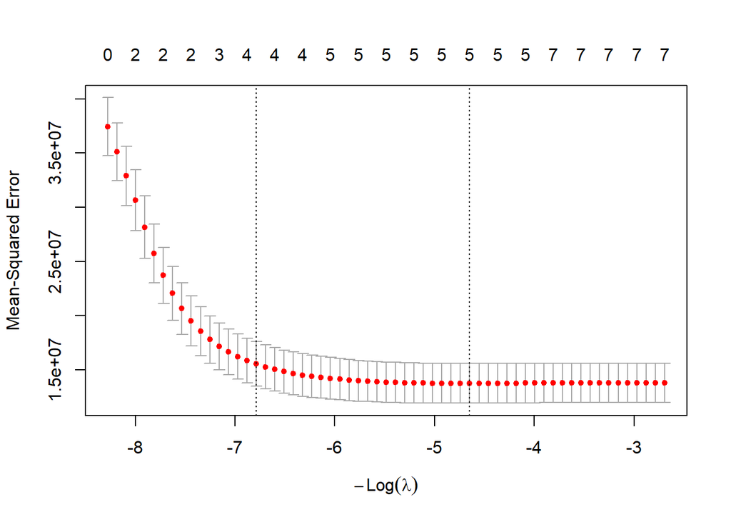

```r
plot(lassoCV)
```

```r
# predict model and find RMSE
model2 <- glmnet(Xtrain, ytrain, alpha = 1, lambda = lassoLambdaMin)
lasso_pred <- predict(model2, s = lassoLambdaMin, newx = Xval)
model2_rmse <- sqrt(mean((yval - lasso_pred)^2))
cat("Model 2 RMSE: ", model2_rmse, "\n")
```

```
## Model 2 RMSE:  4319.652
```

```r
## remaining variables

#store the coefficients
coefLamMin <- predict(lassoCV, s = lassoCV$lambda.min, type = "coefficients")

#Create a data frame for comparing the coefficients
tempdf <-
  data.frame(Variable = row.names(coefLamMin),
             lamMin = as.numeric(coefLamMin))

tempdf
```

```
##          Variable        lamMin
## 1     (Intercept)  9794.4032657
## 2   XPTypeRegular -7349.8986240
## 3    ModeHardCore     0.0000000
## 4           Score     0.6938716
## 5    Eliminations   237.1534176
## 6          Deaths     0.0000000
## 7          Damage     0.5258676
## 8 PlayerTeamScore     8.4464000
```

#### Model3 Analysis and Discussion

For model 3, a PCR model was fit with standardized predictors and using 10 fold cross validation. At first, 7 components were considered for the model, but using an RMSE plot to determine the number of components that should be retained showed that the ideal number to keep is 5. At 5 components the model captured 97.13% of the predictor variance and 65.40% of the response variance, along with an RMSE of 4200.59. This is the lowest RMSE value out of the 3 models so far, being about 85 points lower than model 1.

```r
set.seed(123)
pcrFit <- pcr(TotalXP ~ XPType + Mode + Score + Eliminations + Deaths + Damage + PlayerTeamScore,
                 data = train, center = TRUE, scale = TRUE,
              validation = "CV", segments = 10)
set.seed(NULL)
summary(pcrFit)
```

```
## Data:    X dimension: 393 7
##  Y dimension: 393 1
## Fit method: svdpc
## Number of components considered: 7
##
## VALIDATION: RMSEP
## Cross-validated using 10 random segments.
##        (Intercept)  1 comps  2 comps  3 comps  4 comps  5 comps  6 comps
## CV            6132     4802     4838     4788     3699     3687     3696
## adjCV         6132     4799     4834     4784     3690     3682     3690
##        7 comps
## CV        3706
## adjCV     3700
##
## TRAINING: % variance explained
##          1 comps  2 comps  3 comps  4 comps  5 comps  6 comps  7 comps
## X          36.07    57.75    75.81    87.93    97.13    99.33   100.00
## TotalXP    39.25    39.46    41.43    65.22    65.40    65.52    65.52
```

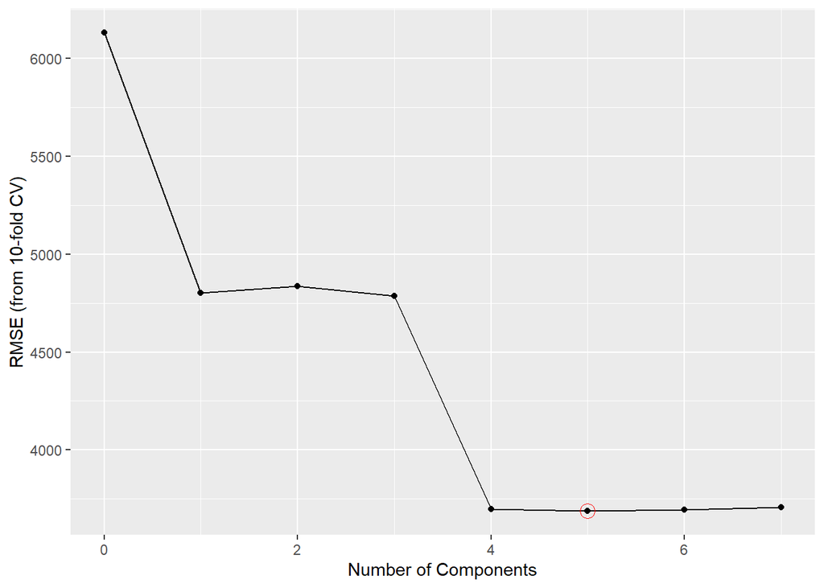

```r
tempRMSE <- RMSEP(pcrFit)

#Create object (ggplotDF) for visualizing
ggplotDF <- data.frame(Components = 0:7,
                       RMSE = tempRMSE$val[1, , ]) #Use [2, , ] for adjusted CV values

#Determine the optimal (lowest) CV RMSE
optMpcr <- which.min(tempRMSE$val[1, , ])

#Create Plot
ggplot(data = ggplotDF, mapping = aes(x = Components, y = RMSE)) +
  geom_line() +
  geom_point() +
  geom_point(data = ggplotDF[optMpcr,], color = "red", shape = 1, size = 4) +
  scale_x_continuous(breaks = seq(0, 40, 2)) +
  labs(x = "Number of Components",
       y = "RMSE (from 10-fold CV)")
```

```r
yhatPCR <- predict(pcrFit, newdata = validation, ncomp = 5)

#MSE and RMSE
MSEpcr <- mean((validation$TotalXP - yhatPCR)^2)
cat("Model 3 MSE: ", MSEpcr, "\n")
```

```
## Model 3 MSE:  17644988
```

```r
RMSEpcr <- sqrt(MSEpcr)
cat("Model 3 RMSE: ", RMSEpcr, "\n")
```

```
## Model 3 RMSE:  4200.594
```

## Task 3

#### Initial Model Building

In building the GAM model (model 4), the significant predictors from the previous models were reviewed to determine which variables should remain. Scatterplots of each were examined to assess if their relationship with TotalXP was linear or non-linear. This led to finding Eliminations to be distinctly non-linear while the other variables were linear. Out of the seven original variables, Damage and Deaths were dropped due to them being mostly insignificant in the previous models and worsening the overall results of the GAM model when added. Therefore, the included predictors are XPType - categorical (dummy), Mode - categorical (dummy), Score - linear, PlayerTeamScore - linear, and Eliminations as a non-linear smoothing term.

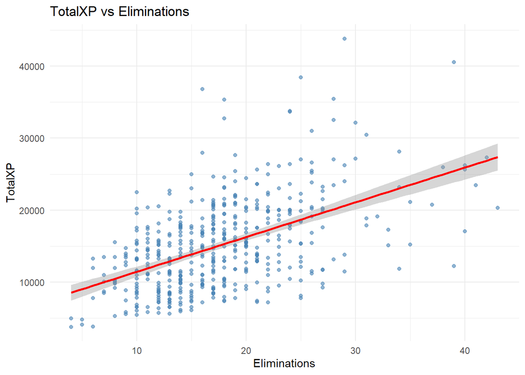

```r
# Scatterplot
ggplot(CODfull, mapping = aes(x = Eliminations, y = TotalXP)) +
  geom_point(alpha = 0.6, color = "steelblue") +
  geom_smooth(method = "lm", se = TRUE, color = "red", linewidth = 1) +
  labs(
    title = "TotalXP vs Eliminations",
    x = "Eliminations",
    y = "TotalXP" ) +
  theme_minimal()
```

#### Analysis, Discussion, and Comparison of Results

Fitting the GAM model with these features showed that all of the features except for PlayerTeamScore are statistically significant contributors to TotalXP. The largest influence is XPTypeRegular with a large negative coefficient of -7367.8, indicating that regular matches result in significantly less XP than double XP which is expected. Score (0.86) and PlayerTeamScore (8.9) are both smaller but positive predictors similar to the previous models. ModeHardcore was the second largest influence with a negative coefficient of (-1414) showing that the hardcore game mode offers less XP than the regular game mode. The smooth term for Eliminations showed substantial non-linearity with an effective degrees of freedom of 8.42. The non-linearity of Eliminations can be seen visually by its plot which shows significant curves. The model overall explained 67.4% of the deviance with an adjusted R^2 of 0.663.

To provide a fair comparison across all four models the RMSE scores of each was evaluated. The GAM model produced an RMSE of 4300, which is worse than model 1 (4286) and model 3 (4201) but better than model 2 (4320). While the GAM model did capture the non-linearity of Eliminations, its improved flexibility did not result in stronger predictive accuracy and generalization. Overall the GAM model finished in the middle of all of the models tested, with the PCR model still being the most preferred.

```r
model4 <- gam(TotalXP ~ XPType + Score + PlayerTeamScore + Mode + s(Eliminations),
              data = train)

summary(model4)
```

```
##
## Family: gaussian
## Link function: identity
##
## Formula:
## TotalXP ~ XPType + Score + PlayerTeamScore + Mode + s(Eliminations)
##
## Parametric coefficients:
##                   Estimate Std. Error t value Pr(>|t|)
## (Intercept)     14923.8486   920.9444  16.205  < 2e-16 ***
## XPTypeRegular   -7367.7754   399.0333 -18.464  < 2e-16 ***
## Score               0.8561     0.2244   3.816 0.000159 ***
## PlayerTeamScore     8.8964     4.8322   1.841 0.066390 .
## ModeHardCore    -1413.6434   414.5056  -3.410 0.000718 ***
## ---
## Signif. codes:  0 '***' 0.001 '**' 0.01 '*' 0.05 '.' 0.1 ' ' 1
##
## Approximate significance of smooth terms:
##                   edf Ref.df     F  p-value
## s(Eliminations) 8.416   8.89 5.938 7.21e-07 ***
## ---
## Signif. codes:  0 '***' 0.001 '**' 0.01 '*' 0.05 '.' 0.1 ' ' 1
##
## R-sq.(adj) =  0.663   Deviance explained = 67.4%
## GCV = 1.3082e+07  Scale est. = 1.2635e+07  n = 393
```

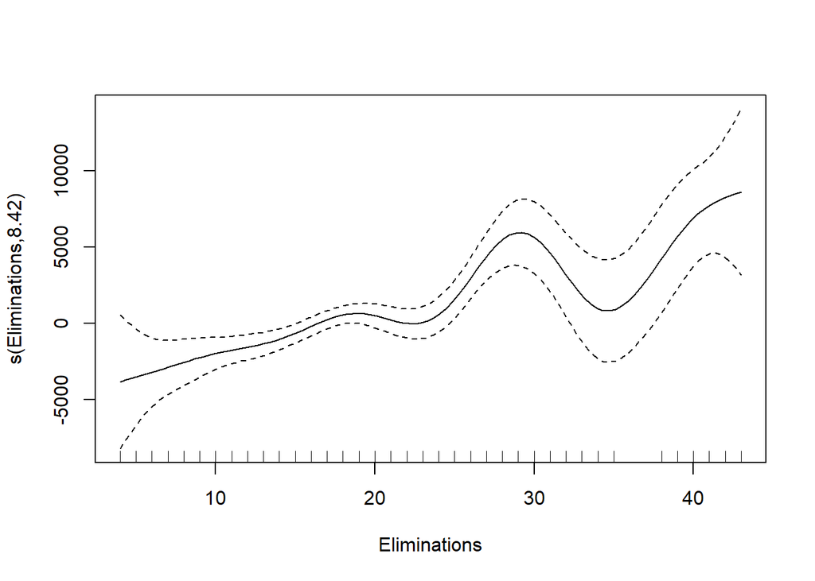

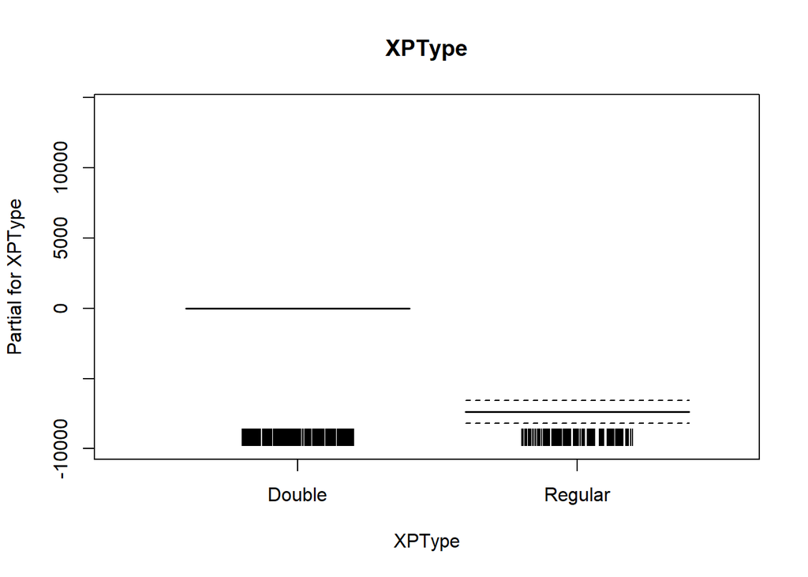

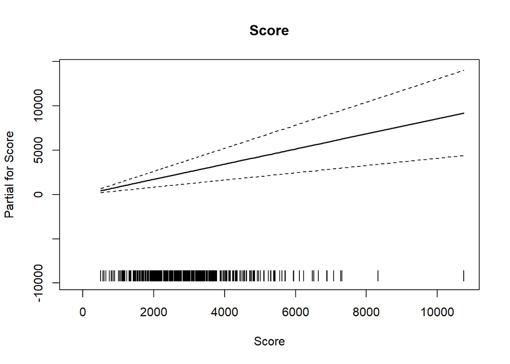

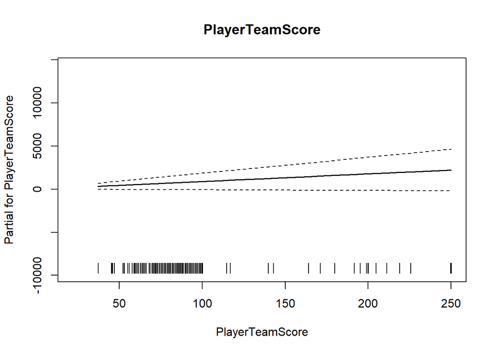

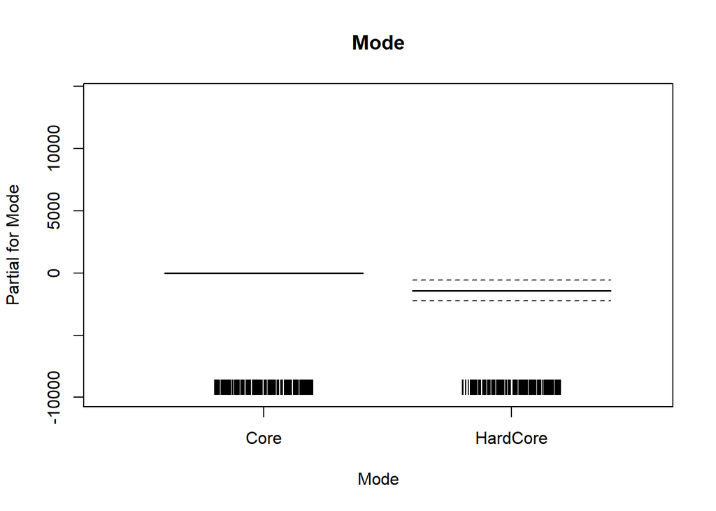

```r
plot(model4, all.terms = TRUE)
```

```r
pred_val <- predict(model4, newdata = validation)
Model4_rmse <- sqrt(mean((validation$TotalXP - pred_val)^2))
cat("Model 4 RMSE: ", Model4_rmse, "\n")
```

```
## Model 4 RMSE:  4299.926
```